# sf geometrical operations

S Ogletree

May 30, 2017

It seemed that I couldn’t find a good visual representation of what some of the operations in `sf` package did, so I went exploring what was available. Many of these tasks might be done in typical GIS but I was eager to see how they might translate to doing geographic analysis in R.

I made up some fake data that approximates what would be encountered in doing work with census data. We have a city boundary and a number of geographical units. The 2 layers are not topologically aligned, as would be expected for a political boundary and aggregation units used for the census.

First, let’s see what I made:

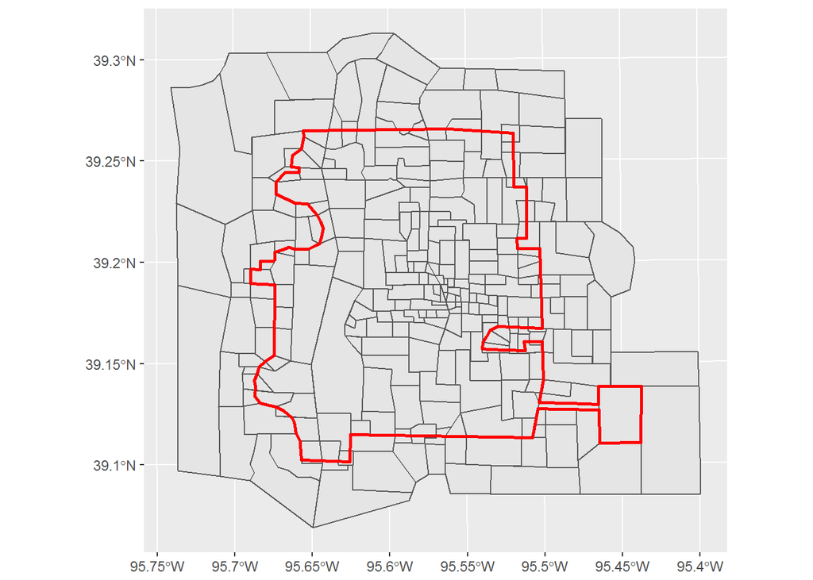

```r
ggplot(geo_units) + geom_sf() + geom_sf(data = city_bnd, colour = "red", fill = NA, size = 1)
```

From the vingette we find:

“The commands `st_intersects`, `st_disjoint`, `st_touches`, `st_crosses`, `st_within`, `st_contains`, `st_overlaps`, `st_equals`, `st_covers`, `st_covered_by`, `st_equals_exact` and `st_is_within_distance` return a sparse matrix with matching (TRUE) indexes, or a full logical matrix”

Thanks to Kyle Walker ([here](http://walkerke.github.io/2017/05/tigris-metros/)) we can use this matrix to subset those units that fall within certain locations relative to the city boundary.

### st_intersects

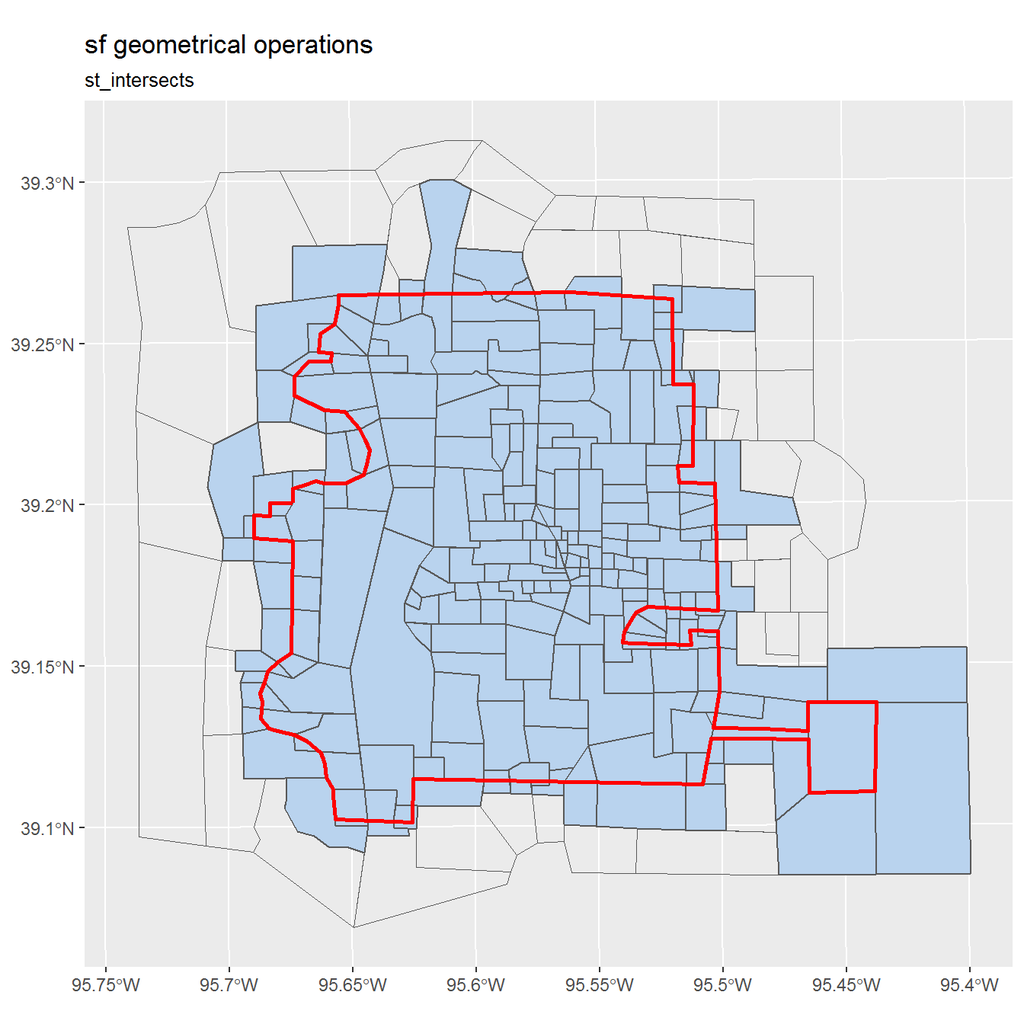

```r
x1 <- st_intersects(geo_units, city_bnd)
x2 <- map_lgl(x1, function(x) {
  if (length(x) == 1) {
    return(TRUE)
  } else {
    return(FALSE)
  }
})

ex1 <- geo_units[x2,]

ggplot() +
  geom_sf(data = geo_units, lwd = .25, fill = NA) +
  geom_sf(data = ex1, fill = "slategray2") +
  geom_sf(data = city_bnd, fill = NA, color = "red", size = 1) +
  ggtitle("sf geometrical operations", subtitle = "st_intersects")
```

We can see that intersecting includes when a ploygon falls on the line of the city bounday too.

### st_disjoint

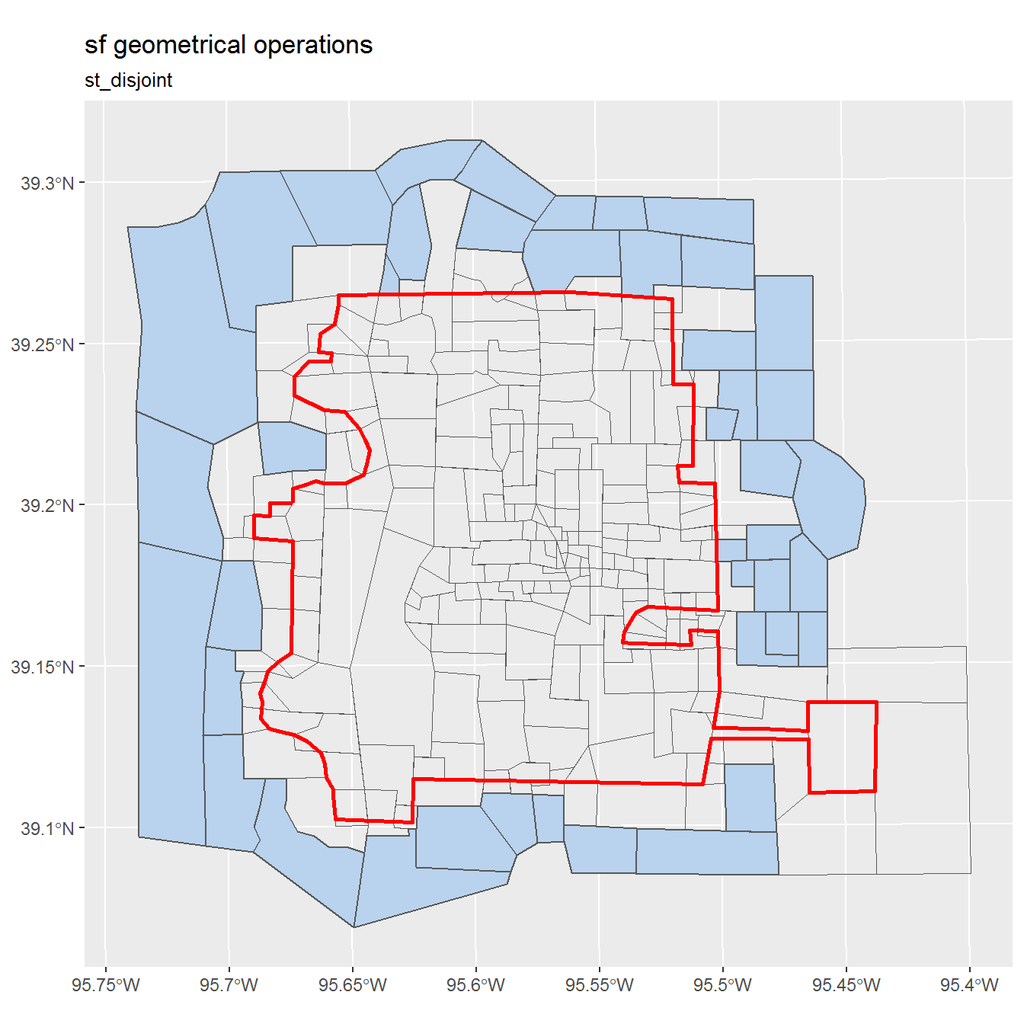

`st_disjoint` appears to be the opposite of `st_intersects`, good to know.

### st_touches

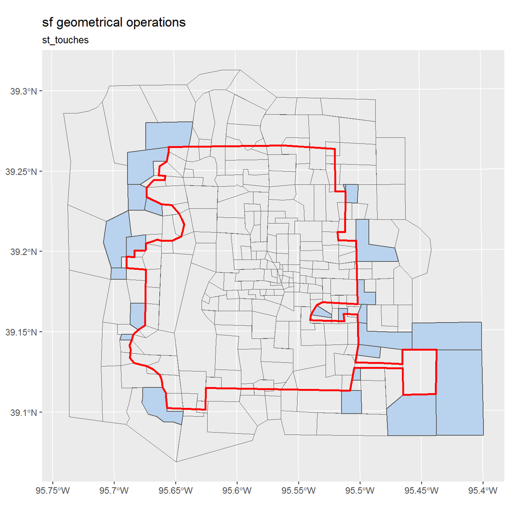

Touches appears to mean on the outside of the city boundary only.

### st_crosses

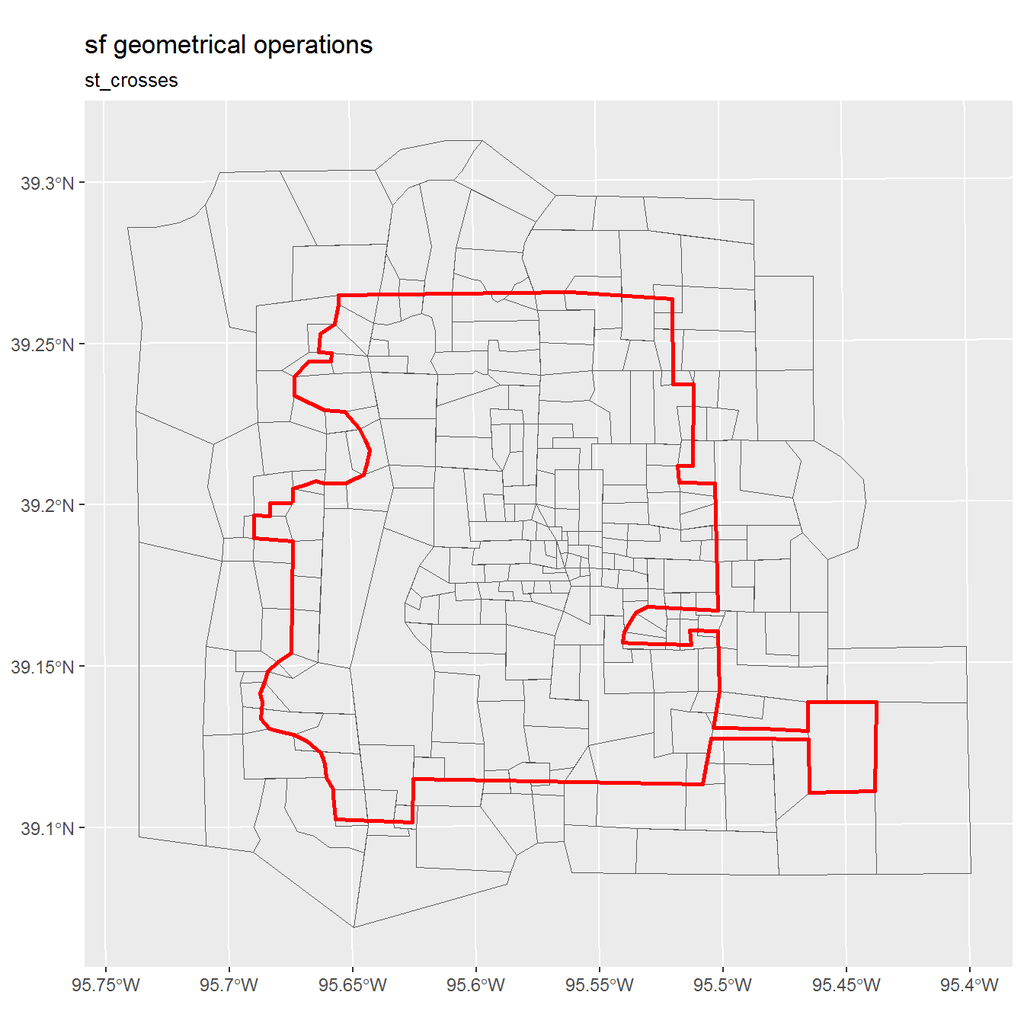

Perhaps this shows that none of the unit polygons crosses the city boundary?

### st_within

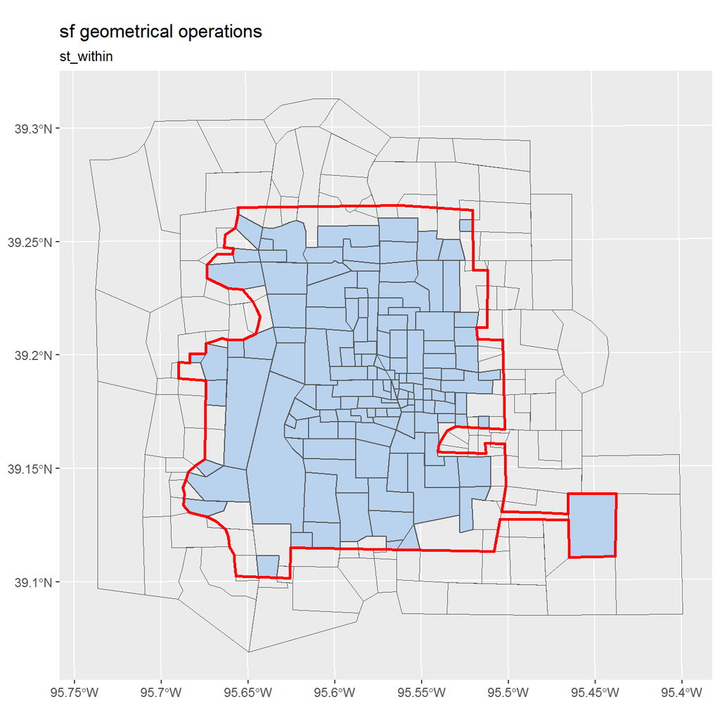

### st_contains

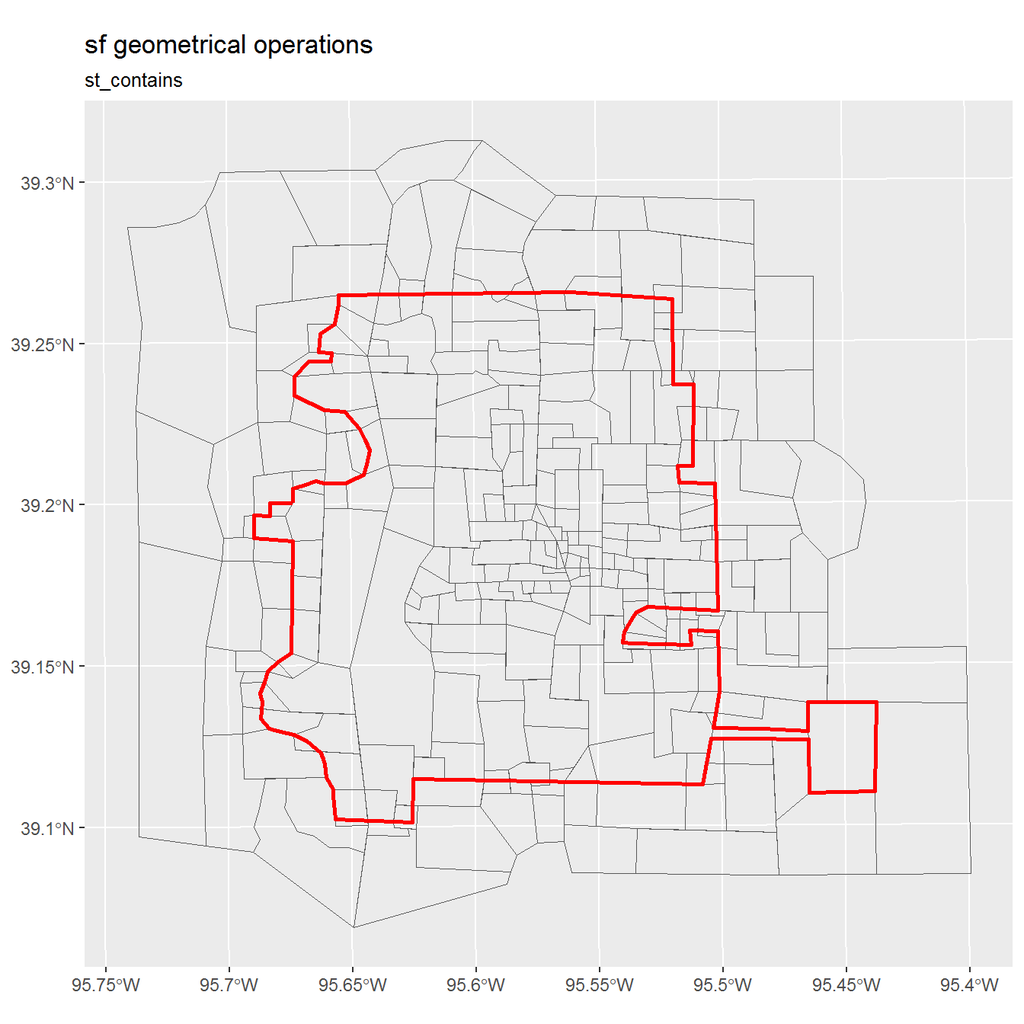

### st_overlaps

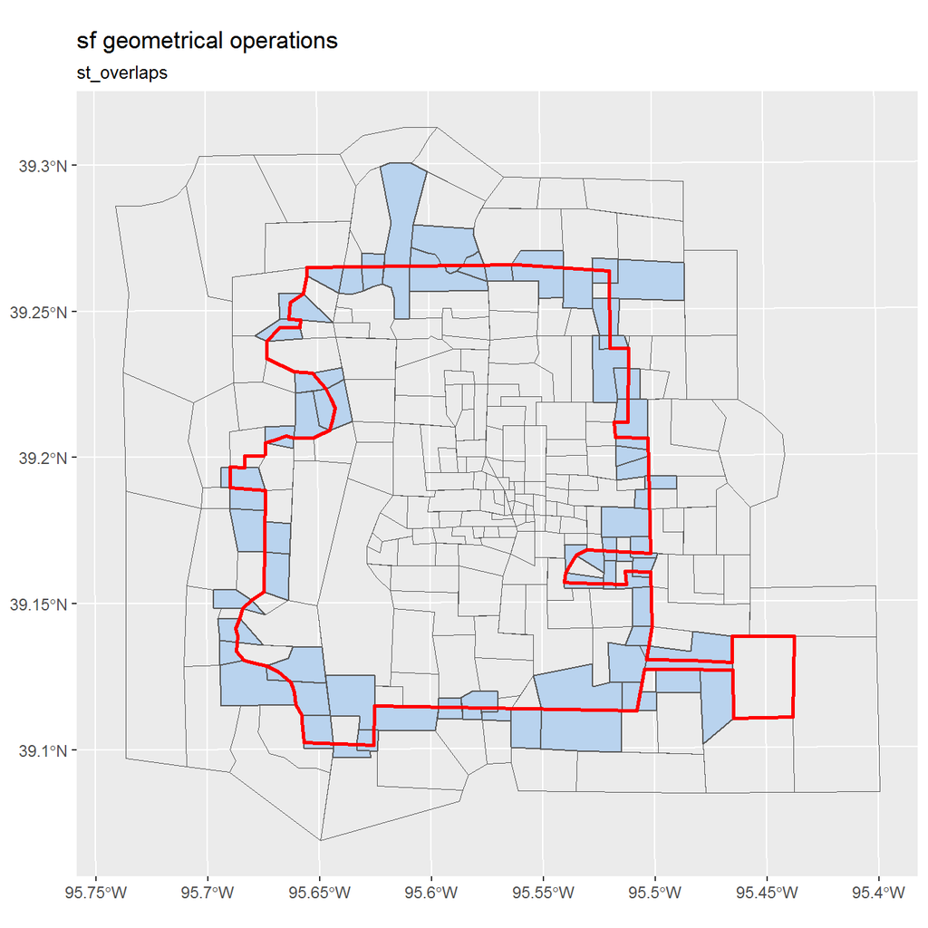

### st_covered_by

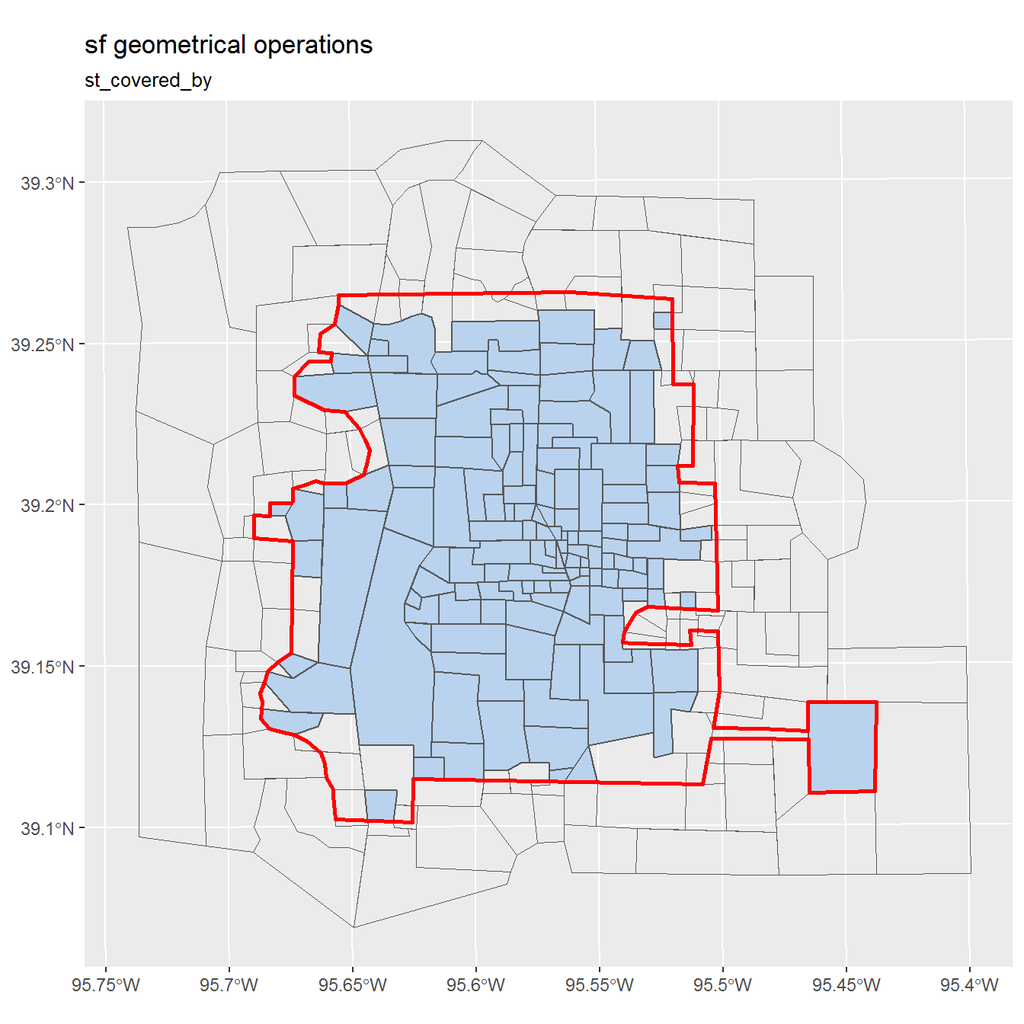